# IE 360 Final Exam – Nilüfer Çetin

Nilüfer Çetin - IE360 - Fall 2020

07 02 2021

## Introduction

In this study, series of hourly produced solar energy from a solar plant in Turkey will be analyzed with appropriate statistical tools. Moreover, based on the findings, forecasting models powered by time series and regression approaches will be constructed. The regression models will be evaluated based on residual standard error and goodness of fit while the models using time series methods will be evaluated by metrics such as AICc and BIC. At last, one model from each approach will be selected and tested on a specified period while dynamically changing the model parameters by use of the observations till two days before the forecast of a day in test period.

It should be stated that, although the main aim is to provide hourly forecasts for the pre-determined days, the statistical analysis and comments are much more valuable than the mere forecast performance since these make this study more scientific.

The data provided for the study consists of hourly produced energy by the solar plant named NIGDE CINGILLI GES in the period from 09-10-2019 till 02-02-2021. The production amounts are gathered along with average temperature, downward radiation flux and total cloud cover from 4 different measurement centers nearby the plant.

To begin with the analysis, the data should be brought to appropriate format, renaming the columns by the abbreviations the data can be seen as,

```
##          Date Hour Production            timestamp cl1 cl2 cl3 cl4 fl1 fl2 fl3
## 1: 2019-10-09    0          0 2019-10-09T00:00:00Z   0   0   0   0   0   0   0
## 2: 2019-10-09    1          0 2019-10-09T01:00:00Z   0   0   0   0   0   0   0
## 3: 2019-10-09    2          0 2019-10-09T02:00:00Z   0   0   0   0   0   0   0
## 4: 2019-10-09    3          0 2019-10-09T03:00:00Z   0   0   0   0   0   0   0
## 5: 2019-10-09    4          0 2019-10-09T04:00:00Z   0   0   0   0   0   0   0
##    fl4   tmp1   tmp2   tmp3   tmp4 sum_day percent
## 1:   0 17.071 16.411 14.531 12.411  195.62       0
## 2:   0 16.949 15.729 13.959 11.939  195.62       0
## 3:   0 15.886 14.636 13.476 11.426  195.62       0
## 4:   0 15.106 13.796 12.856 11.066  195.62       0
## 5:   0 14.910 13.540 12.650 11.220  195.62       0
```

It should be sensible to plot the hourly time series after this point,

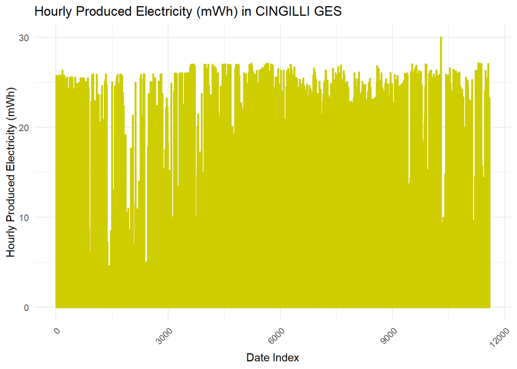

From the plot it can be observed that there are much variation in the series, since this is a solar plant there are many hours, mostly in night time, with zero production. Moreover, there is volatility present even in points that can be considered to be close in time this is due to the nature of the series being affected profoundly by weather conditions, so even small changes in conditions may lead to observable differences in production behavior of the plant. Although it can be argued that the plot reveals a yearly seasonality or cyclic behavior, it might be a better idea to visualize daily aggregated series to discuss this seasonality,

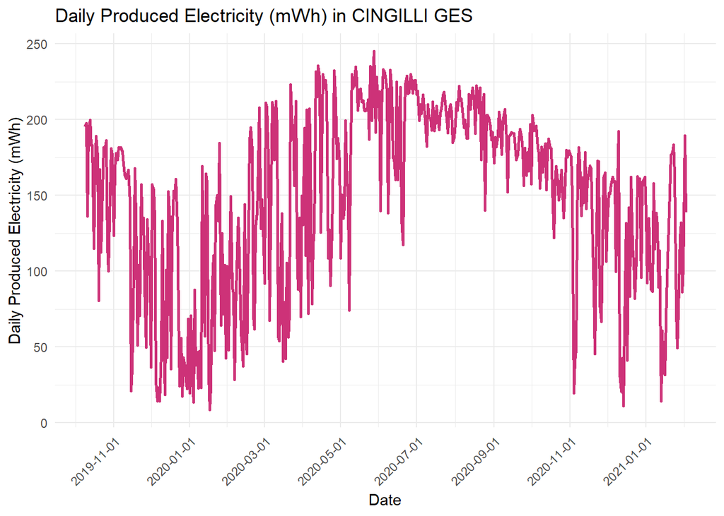

This plot shows the daily summed amount of production of the solar plant in time. It can be claimed that the production volume decreases from summer to winter and increases back from winter to summer. From the last few months’ observations visualized in the right part of the graph, it can be predicted that the series will exhibit a behavior similar to the one occurred in transition from summer to winter in 2019. Though the seasonality is clearly existent, there are two important observations that can be mentioned before continuing the analyses. Firstly, the seasonality may not be entirely the same in different years, the behaviors and levels, shape or rate at which the production values increase or decrease may vary. This might be related to the factors of weather conditions of which some are included in the dataset and be monitored with the data in regression analysis part. Secondly, it can be stated that the variance in summer time is comparably less than the variance in other seasons. This situation might have arose due to the more stable and higher temperatures and amount of sun shine duration in summer. As a result, this decreasing variance in summer season exists in the nature of the problem and although it may violate some assumptions of the models to be constructed, it is still hard to eliminate the behavior from the problem.

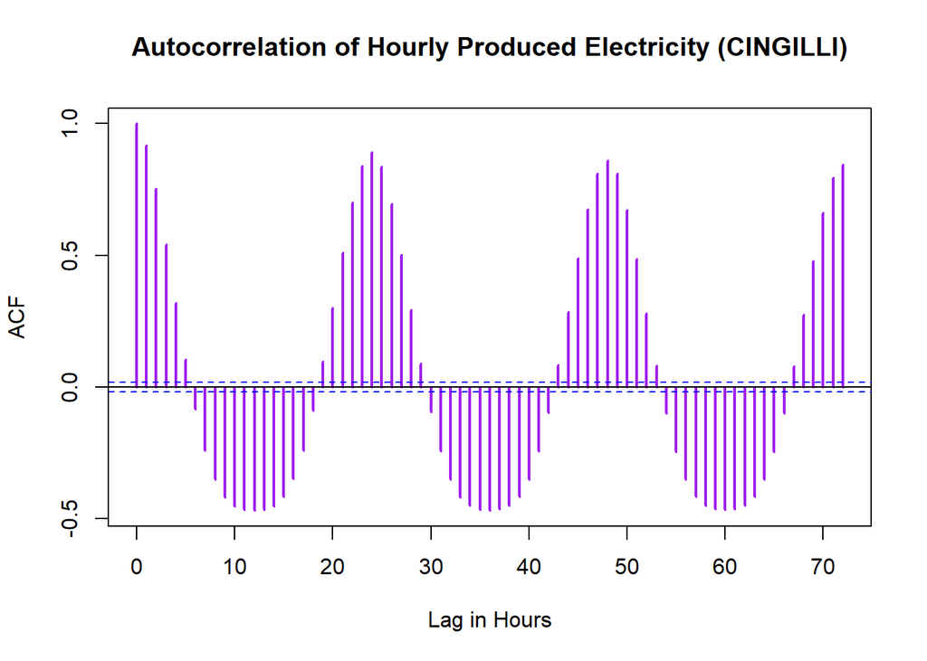

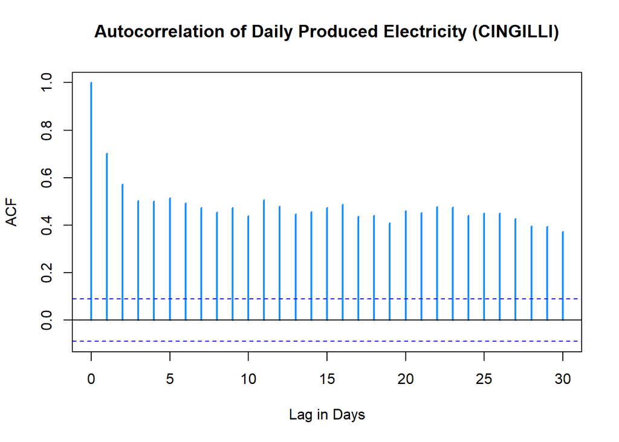

The results are surprising. There is always a positive correlation between the production amounts of days that are close in a year. Although from the other series of energy domain, weekly seasonality can be expected, these series reveal no such pattern. This might be because the consumption or imbalance amounts are determined based on the human actors and in defined settings such as work-days, holidays, and weekends. However, if there are no outside factors affecting production in solar plants, such as rules of close up, change or cleaning etc., it would have been naïve to expect solar production to behave in same manner. The plot on the other hand, shows signals of weak positive partial auto-correlation on 5, 6 or 11 days basis along with lag 1 since in some multiples of these numbers, the auto-correlations attains a local maxima. If partial auto-correlation function is extracted,

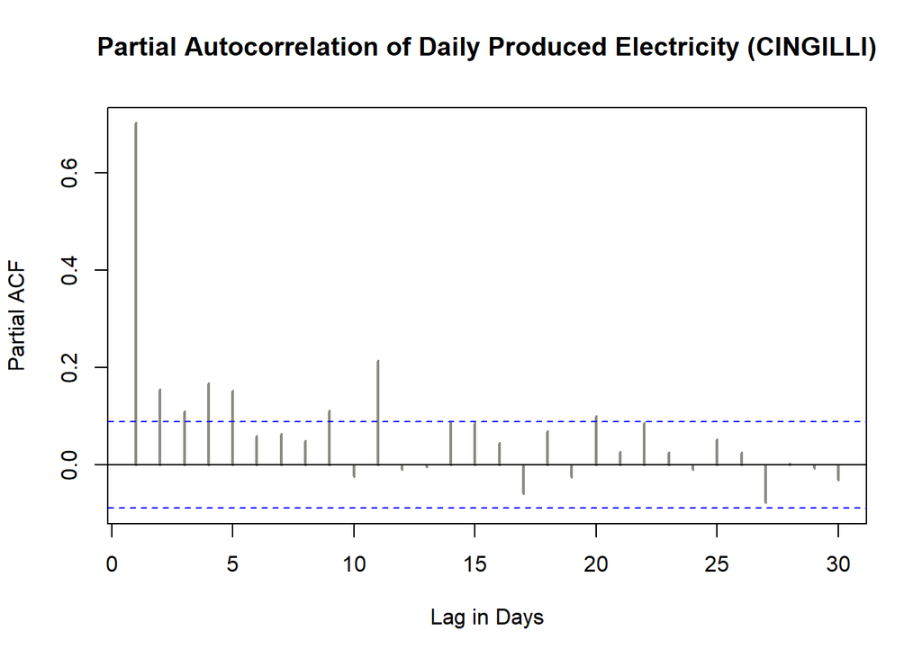

There are several lags in which the level of partial auto-correlation cannot be ignored. Although positive partial serial correlations at small lags seem reasonable because of continuity/similarity in weather conditions, positive correlation at lag 11 is undeniably above the significant threshold. Though a small inspection of related literatures have been carried out to find an explanation, there is no evidence of such behavior in other solar production environments. Nevertheless, since the partial auto-correlation is significant, it will be assumed in the rest of the study that the relation is existent in the production environment of CINGILLI GES maybe because of a regulation related to plant. Lastly, from this comprehensive analysis it can be inferred that the hourly production levels show a daily seasonality, whereas daily aggregated levels show a weak yearly seasonality, with special relation at lag 11.

If the histogram of the production amounts can be visualized,

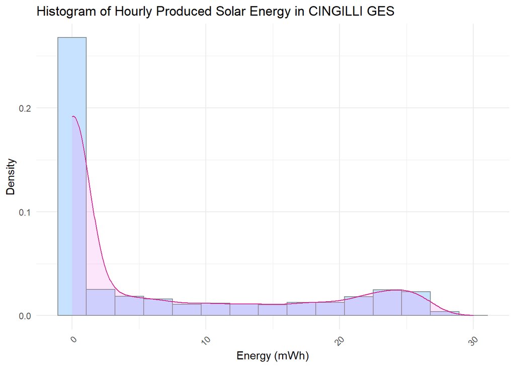

On the first glance, the histogram seems to be coming from an exponential distribution. The accumulation near zero is expected since even in the days with longest sunshine duration, there are many dark hours. If those 0 values were to be extracted from the data, the shape of the distribution will resemble that of a uniform distribution. In several studies conducted before, the main assumption was the normality of observations however in this setting there is no such difference. It can be suspected whether this might hinder the model construction and worsen the model performance in the long run.

Before moving on building models, stationary of the series can be discussed. From the changing mean levels created by seasonality, changing variance and significant auto-correlations at several lags; it is impossible to conclude that the series are stationary. In fact, if Unit Root Test is imposed on the series,

```
##
## #######################
## # KPSS Unit Root Test #
## #######################
##
## Test is of type: mu with 13 lags.
##
## Value of test-statistic is: 2.9377
##
## Critical value for a significance level of:
##                 10pct  5pct 2.5pct  1pct
## critical values 0.347 0.463  0.574 0.739
```

It is revealed that the test statistic is larger than the critical threshold on all significance levels, leading to reject the null hypothesis of series being stationary.

For both time series and regression methods, there are various techniques related to aggregation and disaggregation of the data. Moreover, choice of aggregation, in other words predicting the total production and separating this amount to hourly levels via use of previous data, is also up to the analyst. To sum up, there are actually three principal approaches that will be discussed briefly. From these approaches, by keeping the nature of the problem and forecasting mechanics, appropriate approach for time series decomposition and regression analyses will be selected.

Studying with hourly time series is possible in both methods. In pure time series prediction models, frequency can be selected as 24 for decomposition since daily seasonality is obvious, the models can be powered by differencing at certain lags or ARIMA models. However, production in boundary hours, early morning or early evening, might change from season to season. Although deleting hours with zero production is possible, this may distort the serial correlation calculations leading to future violated assumptions or worsened performance of the model. Differencing the series on 24 or 48 hours might be a more suitable approach on this case since the change in the levels are seem more stable, resembling more of a stationary distribution.

On the regression side, since the approach is entirely data-based it is possible for the coefficients in those boundary hours to be close to zero. Nonetheless, these errors may in the long run hinder the performance of the model. Because the hours in which production start and cease change from season to season, composed variables of month and hour can be used such as Hour 7 of Month 6 or Hour 9 or Season 2. Yet, use of such regressors might complicate the matters since this becomes a more advanced approach compared to the scope of this study. By examination of production start and end in various months or seasons, eliminating those hours from the regression model, later to give 0 forecast to these hours is also a technique that will be used in this study.

Partitioning the hourly time series by hour windows into 24 different daily series is a second well-known technique. In this study, use of this approach is discarded to keep the study on point and not disturb the discussion with 24 different models for each hour. However, in a work environment, use of such models might lead to better performance since there is specialization for every hour level. Although it will not be used in the analysis, the approach may also lead to difficulties if lagged cross correlations with lots of exogenous variables are considered.

A final method can be to construct daily production time series prediction models later to disaggregate the findings into hours by use of linear regression or means analysis using the past data itself. Though this method is highly suitable and practical for the general consumption levels, the solar production is not bound or regulated with human defined factors. The hourly production percentages will probably be approximated roughly leading to inadequate model performance. Nevertheless, considering the prediction environment this method is selected as suitable for the time-series and ARIMA models.

## Time Series Approaches

As mentioned before, there are several paths that can be chosen for the model construction. In prior studies by the analyst, models powered by pure differencing and ARIMA were explored with data from other domains, this time it can be a good idea to go with time series decomposition, building differencing and ARIMA on the random component. If hourly data is selected for this task, since the possibility of model for each hour is ruled out, this leads to 48 step ahead ARIMA calculations. Moreover, the models found by the auto.arima function keep smoothing the forecasted random noise that in few steps, the random noise converges to zero. As continuing with hourly series is rather hard keeping in mind the forecasting setting, aggregating the series to daily level by use of sum function to create a daily model might be a more suitable approach.

Keeping in mind the serial correlation function of the daily series before, to decompose the data seasonality of 11 is selected. It should be noted that this selection might be subject to some doubt, however there are not any lags in which the auto-correlation is said to be profound in related literature. Moreover, it is decided by analyst to keep the auto-correlations at small lags in the data for further differencing before building and searching for ARIMA models. If the series are decomposed in this manner,

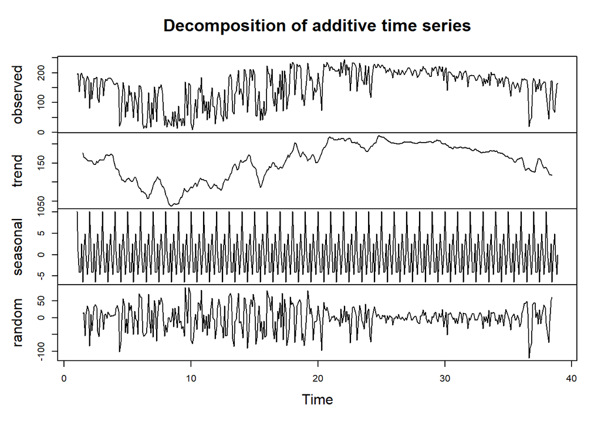

It can be seen that a seasonal component is found and remaining assumed random noise seems stationary excluding the summer time which is a situation in the nature of the problem as discussed before. If a KPSS test is executed,

```
##
## #######################
## # KPSS Unit Root Test #
## #######################
##
## Test is of type: mu with 5 lags.
##
## Value of test-statistic is: 0.0105
##
## Critical value for a significance level of:
##                 10pct  5pct 2.5pct  1pct
## critical values 0.347 0.463  0.574 0.739
```

From the test statistic, the attempt to reject the null hypo-thesis is failed even in smaller significance levels. If random component of the series are observed in a histogram,

[figure not shown]

It can be claimed that the normality assumption is violated within the random series. The series being somehow left-skewed with mode greater than supposed mean, which is 0. To see if differentiation might reveal better fit for normal distribution, ACF plot can be drawn,

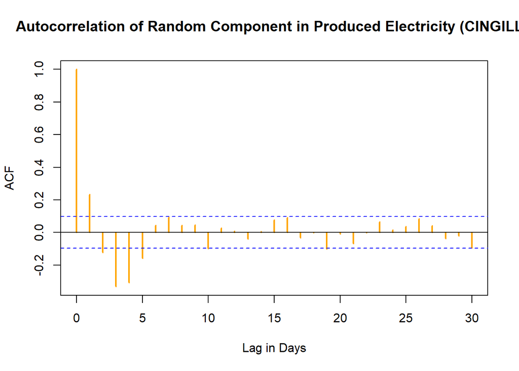

There seems to occur weak positive serial correlation at lag 1 and some negative serial correlations at following lags till 5. To examine the relations in a more clear environment,

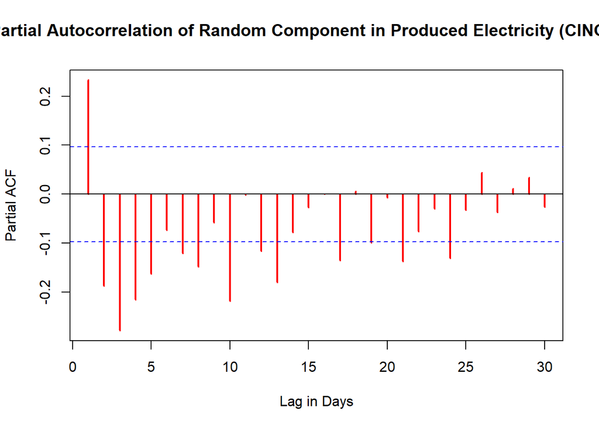

If lag 1 is eliminated, there is revealed to be negative partial correlations in most lags. Although differencing the series by using lagged observations from the predecessor of the period is can lead to a more improved model, keeping in mind the prediction setting this might complicate the forecast part of the story. Moreover, using predictions to construct predictions may reduce the performance of the model.

For differencing two branches are considered by the researcher. One of the differencing approaches will use an aggregated value of lag 2 and lag 3 to difference the random component with. The other method will make use of lag 4 random observation in addition to these. It should be kept in mind that the tuning of differentiation parameters are carried out with respect to auto-correlation weights on these lags. Moreover, several pairs of coefficients are selected and tried out on the series iteratively. It is suitable to state that since the serial correlations have found to be negative, the smoothed random components are added on top of the random component in this process.

As for utilization of lag 2 along with lag 3, coefficients of 0.15 and 0.25 are selected. Other coefficients in neighborhood of these are found to be increasing serial correlations to a significant level on the positive side. Of course, more advanced and detailed parameter selection might have been carried out. With this differentiation the series are,

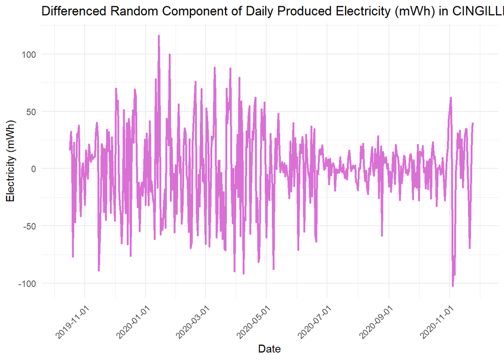

Excluding the summer season, the variance seems to have become smaller. Although there are still some outliers in the series, it might be misleading to comment on all features of the series from the figure.

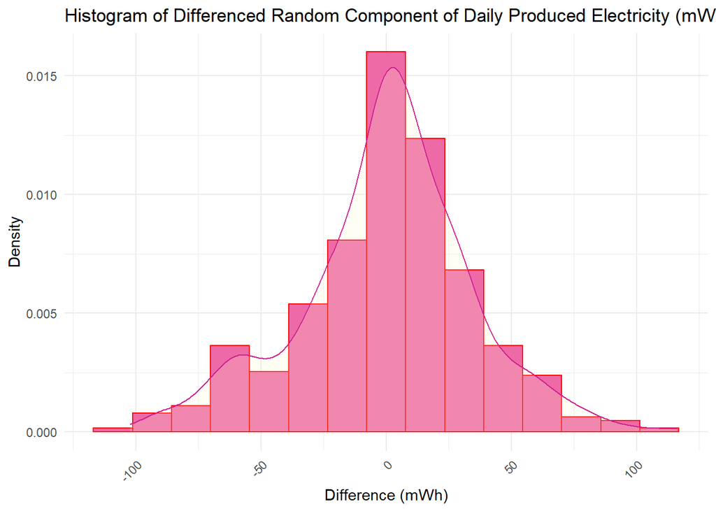

It can be said that a better fit for normal distribution is obtained by the transformation. The distribution of differenced noises are nearly symmetric, with the first positive bin and one of the negative bins having more than expected frequency. Nevertheless, the aim of the study is not to come up with a perfectly differenced and stationary series, as constant variance assumption have already been violated. If an ACF plot is visualized,

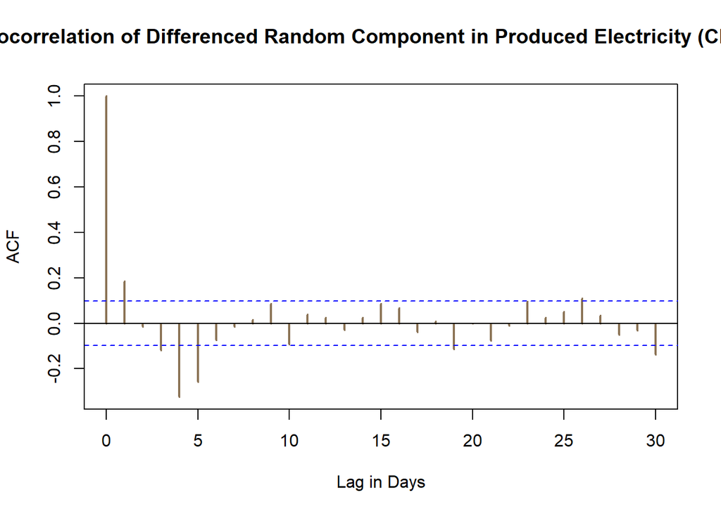

It can be seen that the test statistic have gotten even smaller with differencing. Again rejection of the null hypothesis is failed.

```
##
## #######################
## # KPSS Unit Root Test #
## #######################
##
## Test is of type: mu with 5 lags.
##
## Value of test-statistic is: 0.0069
##
## Critical value for a significance level of:
##                 10pct  5pct 2.5pct  1pct
## critical values 0.347 0.463  0.574 0.739
```

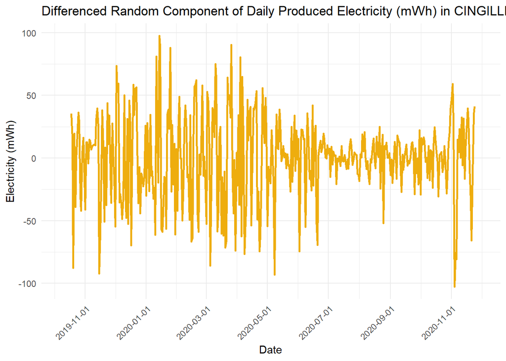

By means of basic inspection, it can be supported that the previous plot is more preferable in terms of less number of outliers and slightly less variance compared to this plot using lag 4. However, this is not a sufficient evidence entirely by itself, histogram is needed to check for normality assumption,

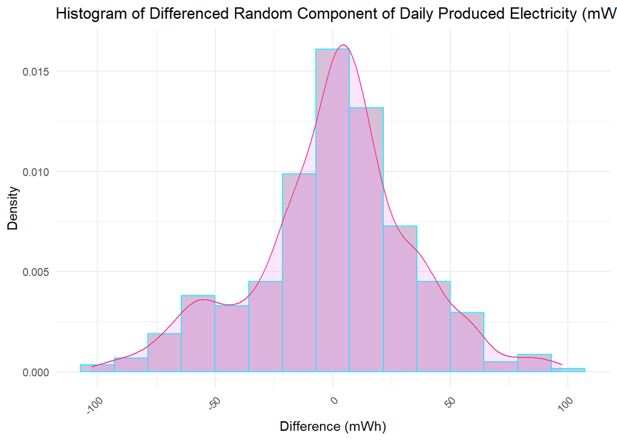

This histogram reveals that there are some problematic classes in the process of fitting the differenced series to a normal distribution. Although the series do not seem to be skewed, there are outlier number of observations in some of the intervals. Considering the normality assumption, first model is a better model than this one. To decide on a final model to apply ARIMA,

[figure not shown]

```
##
##  Fitting models using approximations to speed things up...
##
##  ARIMA(2,0,2) with non-zero mean : 3942.878
##  ARIMA(0,0,0) with non-zero mean : 4024.438
##  ARIMA(1,0,0) with non-zero mean : 4013.195
##  ARIMA(0,0,1) with non-zero mean : 4011.845
##  ARIMA(0,0,0) with zero mean     : 4022.42
##  ARIMA(1,0,2) with non-zero mean : 3952.592
##  ARIMA(2,0,1) with non-zero mean : 3951.794
##  ARIMA(3,0,2) with non-zero mean : Inf
##  ARIMA(2,0,3) with non-zero mean : 3936.443
##  ARIMA(1,0,3) with non-zero mean : 3946.332
##  ARIMA(3,0,3) with non-zero mean : Inf
##  ARIMA(2,0,4) with non-zero mean : 3921.391
##  ARIMA(1,0,4) with non-zero mean : Inf
##  ARIMA(3,0,4) with non-zero mean : Inf
##  ARIMA(2,0,5) with non-zero mean : 3922.88
##  ARIMA(1,0,5) with non-zero mean : Inf
##  ARIMA(3,0,5) with non-zero mean : Inf
##  ARIMA(2,0,4) with zero mean     : 3919.608
##  ARIMA(1,0,4) with zero mean     : 3921.501
##  ARIMA(2,0,3) with zero mean     : 3934.625
##  ARIMA(3,0,4) with zero mean     : Inf
##  ARIMA(2,0,5) with zero mean     : 3921.099
##  ARIMA(1,0,3) with zero mean     : 3944.631
##  ARIMA(1,0,5) with zero mean     : Inf
##  ARIMA(3,0,3) with zero mean     : Inf
##  ARIMA(3,0,5) with zero mean     : Inf
##
##  Now re-fitting the best model(s) without approximations...
##
##  ARIMA(2,0,4) with zero mean     : Inf
##  ARIMA(2,0,5) with zero mean     : 3894.087
##
##  Best model: ARIMA(2,0,5) with zero mean
```

The decision to use AICc values is reasonable and auto.arima function selects the minimum possible AICc valued model by using search techniques. Two auto-regressive and five moving averages are found in the model, this actually shows that the amount of differencing is not enough to exclude autocorrelations within the remaining series.

By inversely transforming the predicted random component and dynamically updating the dataset to use for decomposition(freq=11) and ARIMA(2,0,5). Daily forecasts for the test period are gathered,

```
##           Date Forecast
##  1: 2020-12-01 111.7139
##  2: 2020-12-02 111.0092
##  3: 2020-12-03 122.2133
##  4: 2020-12-04 120.5473
##  5: 2020-12-05 126.1734
##  6: 2020-12-06 115.5759
##  7: 2020-12-07 118.6940
##  8: 2020-12-08 128.1844
##  9: 2020-12-09 137.9064
## 10: 2020-12-10 141.5885
```

Before providing hourly forecasts, two linear regression models to distribute hourly forecasts can be written using the December 2019 and January 2020 data from the training data set. The models are separated by their months however, this may also be unrealistic as the sunshine durations reaches its global minimum on late December. Nevertheless, as a practical approach it is valid. Hourly forecasts are,

```
##           Date Hour Production forecast  residual
##  1: 2020-12-01    0       0.00 0.000000  0.000000
##  2: 2020-12-01    1       0.00 0.000000  0.000000
##  3: 2020-12-01    2       0.00 0.000000  0.000000
##  4: 2020-12-01    3       0.00 0.000000  0.000000
##  5: 2020-12-01    4       0.00 0.000000  0.000000
##  6: 2020-12-01    5       0.00 0.000000  0.000000
##  7: 2020-12-01    6       0.00 0.000000  0.000000
##  8: 2020-12-01    7       0.00 0.000000  0.000000
##  9: 2020-12-01    8       1.51 0.000000  1.510000
## 10: 2020-12-01    9       5.29 8.214532 -2.924532
```

## Linear Regression

Before elaborating on linear regression, plot of the data points in time can be re-drawn,

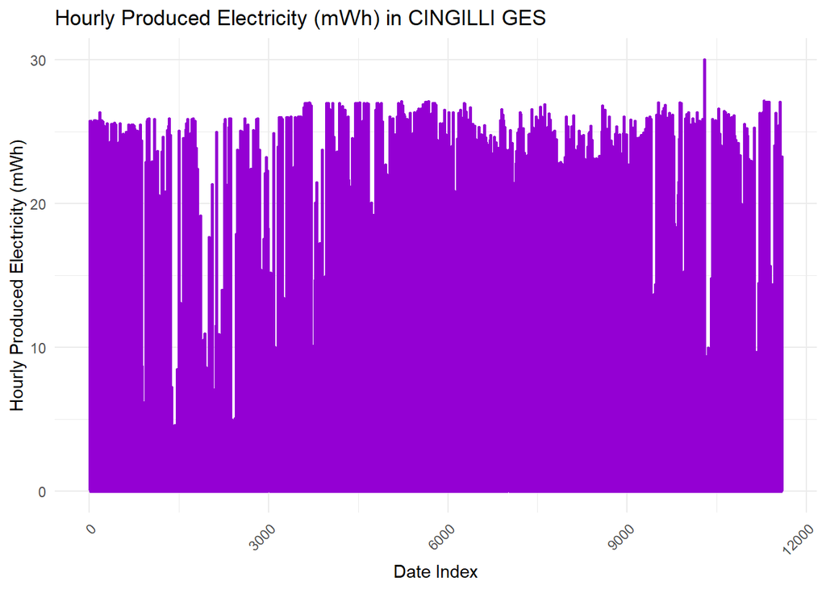

On the regression side, hourly series regression will be selected as of method. From inspection of dataset, examining the monthly mean hourly production amounts and use of geography knowledge, certain hours in certain months are ruled out from the dataset, later to be filled with zero forecasts. List of these hours can be found in code.

As discussed before, after the exclusion of these hours a histogram of the remaining observations and resembling that of uniform distribution or inverse normal distribution, if exists, can be shown,

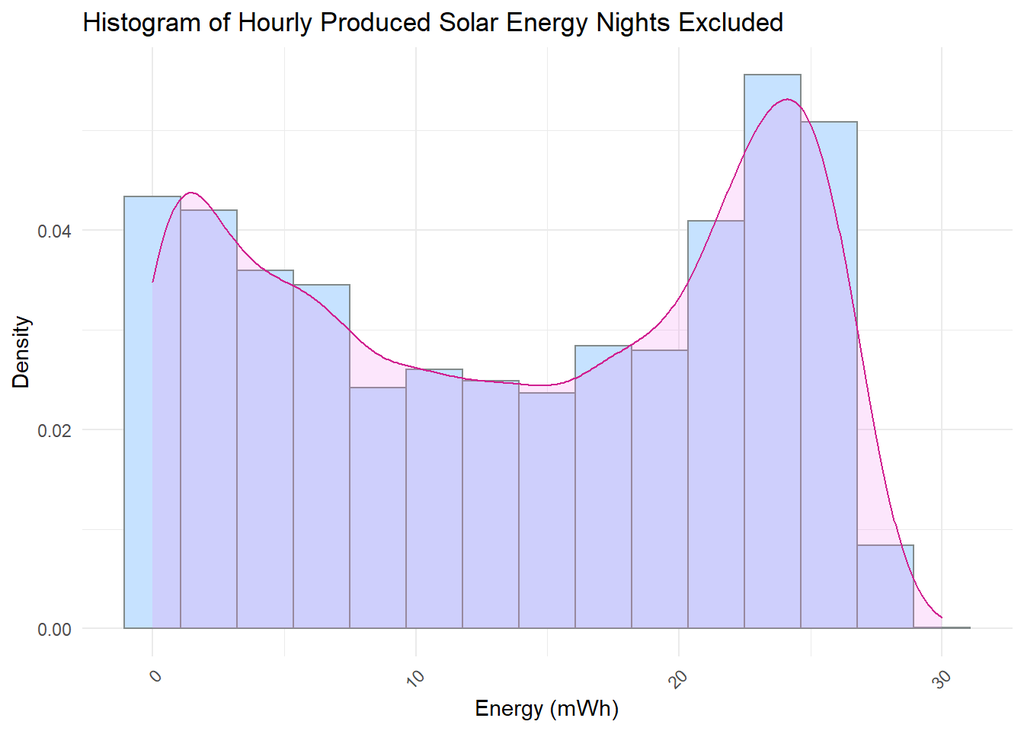

First of all, from the discussions made earlier it is reasonable to think that the series show a micro (daily) and a macro (yearly) seasonality. Daily seasonality can be easily modelled by use of factorization of hours remaining within the dataset. For modelling the yearly seasonality various paths can be taken. For example, roughly a year can be assumed to be consisting of 2 runs, one increasing and one decreasing and constant periods in between. However, modeling this may become an oversimplification as there are constant or opposing periods within the runs itself. Instead of this, factorization of months can be used. If a model is obtained in that manner,

```
##
## Call:
## lm(formula = Production ~ as.factor(Hour) + as.factor(month(Date)),
##     data = out %>% filter(Date < "2020-11-30"))
##
## Residuals:
##      Min       1Q   Median       3Q      Max
## -24.8320  -2.2740   0.5092   2.9216  15.9811
##
## Coefficients:
##                          Estimate Std. Error t value Pr(>|t|)
## (Intercept)               -9.3768     1.0343  -9.066  < 2e-16 ***
## as.factor(Hour)7           4.2046     1.0819   3.886 0.000103 ***
## as.factor(Hour)8          10.7163     1.0201  10.506  < 2e-16 ***
## as.factor(Hour)9          16.8208     1.0152  16.570  < 2e-16 ***
## as.factor(Hour)10         21.2174     1.0152  20.901  < 2e-16 ***
## as.factor(Hour)11         23.0404     1.0152  22.696  < 2e-16 ***
## as.factor(Hour)12         22.9184     1.0152  22.576  < 2e-16 ***
## as.factor(Hour)13         22.1435     1.0152  21.813  < 2e-16 ***
## as.factor(Hour)14         20.5553     1.0152  20.248  < 2e-16 ***
## as.factor(Hour)15         17.4657     1.0152  17.205  < 2e-16 ***
## as.factor(Hour)16         12.3538     1.0152  12.169  < 2e-16 ***
## as.factor(Hour)17          6.8628     1.0152   6.760 1.55e-11 ***
## as.factor(Hour)18          1.8371     1.0420   1.763 0.077963 .
## as.factor(Hour)19         -1.2024     1.0819  -1.111 0.266453
## as.factor(month(Date))2    2.9922     0.4365   6.855 8.06e-12 ***
## as.factor(month(Date))3    5.5379     0.4216  13.136  < 2e-16 ***
## as.factor(month(Date))4    8.5007     0.4247  20.015  < 2e-16 ***
## as.factor(month(Date))5   10.4931     0.4107  25.552  < 2e-16 ***
## as.factor(month(Date))6   10.9038     0.4134  26.378  < 2e-16 ***
## as.factor(month(Date))7   11.1844     0.4107  27.235  < 2e-16 ***
## as.factor(month(Date))8   11.1684     0.4107  27.196  < 2e-16 ***
## as.factor(month(Date))9    9.8137     0.4247  23.107  < 2e-16 ***
## as.factor(month(Date))10   8.3719     0.3840  21.802  < 2e-16 ***
## as.factor(month(Date))11   5.1007     0.3784  13.478  < 2e-16 ***
## as.factor(month(Date))12  -0.4076     0.4397  -0.927 0.353970
## ---
## Signif. codes:  0 '***' 0.001 '**' 0.01 '*' 0.05 '.' 0.1 ' ' 1
##
## Residual standard error: 5.193 on 4583 degrees of freedom
## Multiple R-squared:  0.6644, Adjusted R-squared:  0.6627
## F-statistic: 378.1 on 24 and 4583 DF,  p-value: < 2.2e-16
```

Although the goodness of fit seems satisfactory and almost all the variables are statistically significant, use of weather conditions can strengthen the model. It is known priory that the temperature values being greater than a threshold impair the production performance. In addition, it is examined by the researcher that flux can still be high in hours just after the sunset and lower in hours after the sunrise. As a result, mean cloud level of 4 nearby centers can be a more fulfilling regressor to use in the model. If the scatter plots of residuals versus mean cloud layer on months are visualized,

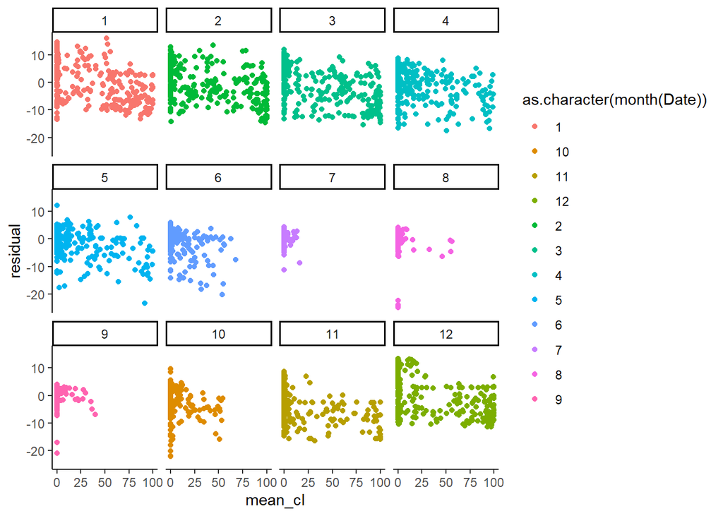

Though there are many observations in which the cloud layer is not existent, a negative correlation can be drawn from the plots. A correlation coefficient of -0.4 is shown below.

```
##
##  Pearson's product-moment correlation
##
## data:  out$mean_cl and out$residual
## t = -29.997, df = 4606, p-value < 2.2e-16
## alternative hypothesis: true correlation is not equal to 0
## 95 percent confidence interval:
##  -0.4281471 -0.3798299
## sample estimates:
##        cor
## -0.4042705
```

If mean cloud layer is added as a predictor to the previous model,

```
##
## Call:
## lm(formula = Production ~ as.factor(Hour) + as.factor(month(Date)) +
##     mean_cl, data = out %>% filter(Date < "2020-11-30"))
##
## Residuals:
##      Min       1Q   Median       3Q      Max
## -24.7596  -1.8569   0.4178   2.6161  17.3756
##
## Coefficients:
##                           Estimate Std. Error t value Pr(>|t|)
## (Intercept)              -5.652299   0.920896  -6.138 9.07e-10 ***
## as.factor(Hour)7          4.145182   0.957054   4.331 1.51e-05 ***
## as.factor(Hour)8         10.645142   0.902344  11.797  < 2e-16 ***
## as.factor(Hour)9         16.820102   0.898001  18.731  < 2e-16 ***
## as.factor(Hour)10        21.126687   0.898004  23.526  < 2e-16 ***
## as.factor(Hour)11        22.944898   0.898005  25.551  < 2e-16 ***
## as.factor(Hour)12        22.832782   0.898004  25.426  < 2e-16 ***
## as.factor(Hour)13        22.111430   0.898001  24.623  < 2e-16 ***
## as.factor(Hour)14        20.579202   0.898001  22.917  < 2e-16 ***
## as.factor(Hour)15        17.541384   0.898003  19.534  < 2e-16 ***
## as.factor(Hour)16        12.701182   0.898053  14.143  < 2e-16 ***
## as.factor(Hour)17         7.226339   0.898058   8.047 1.08e-15 ***
## as.factor(Hour)18         2.135507   0.921788   2.317   0.0206 *
## as.factor(Hour)19        -1.007880   0.957068  -1.053   0.2924
## as.factor(month(Date))2   2.928389   0.386102   7.585 4.02e-14 ***
## as.factor(month(Date))3   4.956313   0.373295  13.277  < 2e-16 ***
## as.factor(month(Date))4   6.719326   0.378994  17.729  < 2e-16 ***
## as.factor(month(Date))5   8.076465   0.369518  21.857  < 2e-16 ***
## as.factor(month(Date))6   7.647741   0.376862  20.293  < 2e-16 ***
## as.factor(month(Date))7   7.425248   0.378217  19.632  < 2e-16 ***
## as.factor(month(Date))8   7.467030   0.377769  19.766  < 2e-16 ***
## as.factor(month(Date))9   6.138771   0.389540  15.759  < 2e-16 ***
## as.factor(month(Date))10  4.869539   0.353558  13.773  < 2e-16 ***
## as.factor(month(Date))11  2.152194   0.344802   6.242 4.72e-10 ***
## as.factor(month(Date))12 -0.682475   0.389026  -1.754   0.0794 .
## mean_cl                  -0.100380   0.002811 -35.704  < 2e-16 ***
## ---
## Signif. codes:  0 '***' 0.001 '**' 0.01 '*' 0.05 '.' 0.1 ' ' 1
##
## Residual standard error: 4.594 on 4582 degrees of freedom
## Multiple R-squared:  0.7375, Adjusted R-squared:  0.736
## F-statistic: 514.9 on 25 and 4582 DF,  p-value: < 2.2e-16
```

The added regressor is highly significant. Moreover, the residual standard error have decreased in a considerable amount. Before checking the residual assumptions, another predictor related to the weather conditions can be added to the model. If the scatter plot of residuals of the model versus mean flux radiation is shown in a similar fashion to the previous plot,

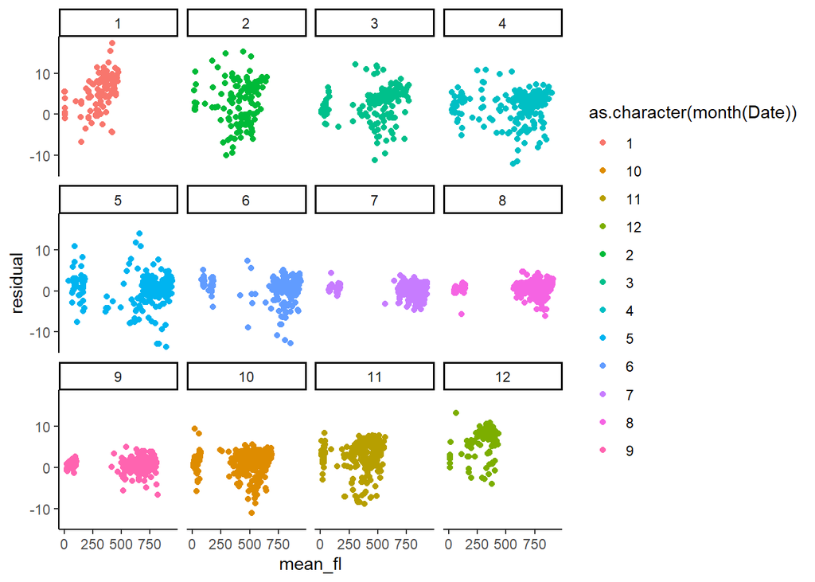

It can be stated that some extent of increase in residuals are related to the increase in mean amount of flux. However, this relation is only profoundly existent in colder months of the year. By visual inspection it is decided that; January, February, March, November and December observations of mean flux can be added to the previous model,

```
##
## Call:
## lm(formula = Production ~ as.factor(Hour) + as.factor(month(Date)) +
##     mean_cl + mean_fl, data = out %>% filter(Date < "2020-11-30"))
##
## Residuals:
##      Min       1Q   Median       3Q      Max
## -16.7021  -2.0715   0.1314   2.3296  16.6712
##
## Coefficients:
##                            Estimate Std. Error t value Pr(>|t|)
## (Intercept)              -1.8738646  0.8467898  -2.213  0.02695 *
## as.factor(Hour)7          4.2053127  0.8708049   4.829 1.42e-06 ***
## as.factor(Hour)8          8.4233217  0.8241697  10.220  < 2e-16 ***
## as.factor(Hour)9         13.6075199  0.8236673  16.521  < 2e-16 ***
## as.factor(Hour)10        13.1936955  0.8565063  15.404  < 2e-16 ***
## as.factor(Hour)11        14.1081468  0.8657346  16.296  < 2e-16 ***
## as.factor(Hour)12        13.3524142  0.8728446  15.298  < 2e-16 ***
## as.factor(Hour)13        12.1960919  0.8778954  13.892  < 2e-16 ***
## as.factor(Hour)14        10.6421223  0.8781529  12.119  < 2e-16 ***
## as.factor(Hour)15         7.6570440  0.8775305   8.726  < 2e-16 ***
## as.factor(Hour)16         4.9783015  0.8545330   5.826 6.07e-09 ***
## as.factor(Hour)17         2.1702643  0.8333655   2.604  0.00924 **
## as.factor(Hour)18         0.7357628  0.8399386   0.876  0.38109
## as.factor(Hour)19        -1.0190952  0.8708156  -1.170  0.24195
## as.factor(month(Date))2   1.5792887  0.3540114   4.461 8.35e-06 ***
## as.factor(month(Date))3   1.8994516  0.3537839   5.369 8.31e-08 ***
## as.factor(month(Date))4   4.5672824  0.3518093  12.982  < 2e-16 ***
## as.factor(month(Date))5   4.2619000  0.3581898  11.898  < 2e-16 ***
## as.factor(month(Date))6   3.7377317  0.3655280  10.226  < 2e-16 ***
## as.factor(month(Date))7   3.0790981  0.3717978   8.282  < 2e-16 ***
## as.factor(month(Date))8   3.7559956  0.3641257  10.315  < 2e-16 ***
## as.factor(month(Date))9   3.7106627  0.3630505  10.221  < 2e-16 ***
## as.factor(month(Date))10  4.1576274  0.3225194  12.891  < 2e-16 ***
## as.factor(month(Date))11  1.8881224  0.3138442   6.016 1.93e-09 ***
## as.factor(month(Date))12 -0.1047495  0.3544601  -0.296  0.76761
## mean_cl                  -0.0721858  0.0027161 -26.577  < 2e-16 ***
## mean_fl                   0.0128173  0.0004151  30.881  < 2e-16 ***
## ---
## Signif. codes:  0 '***' 0.001 '**' 0.01 '*' 0.05 '.' 0.1 ' ' 1
##
## Residual standard error: 4.18 on 4581 degrees of freedom
## Multiple R-squared:  0.7827, Adjusted R-squared:  0.7815
## F-statistic: 634.7 on 26 and 4581 DF,  p-value: < 2.2e-16
```

A better fit along with visibly reduced residual standard error are created by the model. If the residuals are checked,

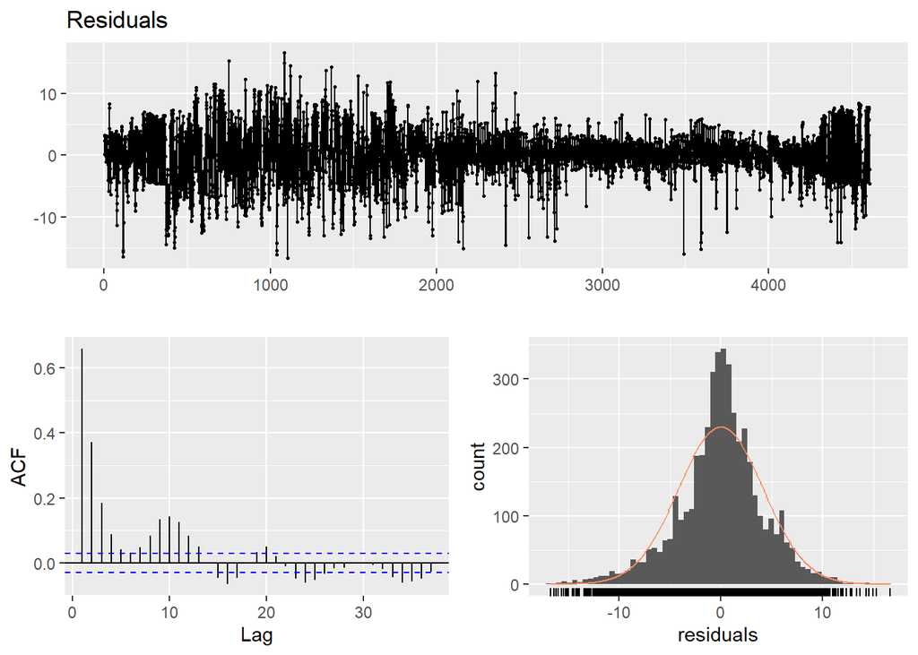

```
##
##  Breusch-Godfrey test for serial correlation of order up to 30
##
## data:  Residuals
## LM test = 2159.7, df = 30, p-value < 2.2e-16
```

Just like the time series approaches, the constant variance assumption of the residuals are violated by the summer season. Fit to normal distribution is distorted at some bins, although the distribution is very similar to a normal. Significant auto-correlations exist in the residuals, with special interest in lag 1 and lag 10. Serial correlation at lag 10 might probably have arose due to deletion of 13, 14 or 15 hours from most of the days. Although addition of these as auto-regressors can heavily influence the model performance in a good way, once the forecasting setting is thought, those regressors can only benefit from the forecasts that have not created residuals yet. After the incorporation of temperature data, use of lag 20 residual will be discussed. If temperature versus residual points are visualized,

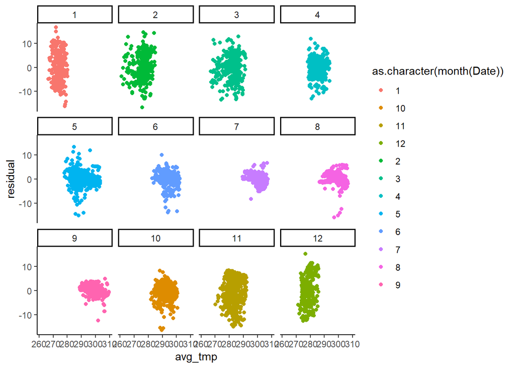

It can be commented that in some months excluding the interval of May to September, there seems to be a somewhat positive correlation with average temperature values. Those values are written by turning into absolute temperature since negative temperatures on winter months may mislead the function to find a sub-optimal coefficient for regression. To keep the discussion simple there are two ways that can be processed. A solution would be to delete average temperatures for months with no clear sign of correlation. If the months that are defined before are excluded from the temperature effect the model is,

```
##
## Call:
## lm(formula = Production ~ as.factor(Hour) + as.factor(month(Date)) +
##     mean_cl + mean_fl + avg_tmp, data = out %>% filter(Date <
##     "2020-11-30"))
##
## Residuals:
##     Min      1Q  Median      3Q     Max
## -16.504  -2.009   0.146   2.283  17.000
##
## Coefficients:
##                            Estimate Std. Error t value Pr(>|t|)
## (Intercept)              -4.129e+01  6.296e+00  -6.558 6.06e-11 ***
## as.factor(Hour)7          4.210e+00  8.671e-01   4.855 1.25e-06 ***
## as.factor(Hour)8          8.787e+00  8.227e-01  10.681  < 2e-16 ***
## as.factor(Hour)9          1.379e+01  8.207e-01  16.805  < 2e-16 ***
## as.factor(Hour)10         1.319e+01  8.529e-01  15.462  < 2e-16 ***
## as.factor(Hour)11         1.399e+01  8.623e-01  16.229  < 2e-16 ***
## as.factor(Hour)12         1.315e+01  8.698e-01  15.117  < 2e-16 ***
## as.factor(Hour)13         1.192e+01  8.753e-01  13.621  < 2e-16 ***
## as.factor(Hour)14         1.032e+01  8.759e-01  11.786  < 2e-16 ***
## as.factor(Hour)15         7.317e+00  8.755e-01   8.358  < 2e-16 ***
## as.factor(Hour)16         4.673e+00  8.523e-01   5.483 4.40e-08 ***
## as.factor(Hour)17         1.985e+00  8.304e-01   2.391 0.016851 *
## as.factor(Hour)18         6.629e-01  8.365e-01   0.793 0.428107
## as.factor(Hour)19        -1.031e+00  8.671e-01  -1.188 0.234733
## as.factor(month(Date))2   1.296e+00  3.554e-01   3.646 0.000269 ***
## as.factor(month(Date))3   7.297e-01  3.980e-01   1.833 0.066800 .
## as.factor(month(Date))4   2.894e+00  4.392e-01   6.590 4.88e-11 ***
## as.factor(month(Date))5   4.360e+01  6.237e+00   6.990 3.14e-12 ***
## as.factor(month(Date))6   4.312e+01  6.245e+00   6.905 5.71e-12 ***
## as.factor(month(Date))7   4.249e+01  6.249e+00   6.799 1.19e-11 ***
## as.factor(month(Date))8   4.317e+01  6.250e+00   6.908 5.61e-12 ***
## as.factor(month(Date))9   4.314e+01  6.253e+00   6.900 5.91e-12 ***
## as.factor(month(Date))10  1.641e+00  5.117e-01   3.207 0.001349 **
## as.factor(month(Date))11  6.226e-01  3.712e-01   1.677 0.093582 .
## as.factor(month(Date))12 -7.447e-01  3.672e-01  -2.028 0.042614 *
## mean_cl                  -6.592e-02  2.880e-03 -22.886  < 2e-16 ***
## mean_fl                   1.303e-02  4.146e-04  31.416  < 2e-16 ***
## avg_tmp                   1.434e-01  2.270e-02   6.317 2.92e-10 ***
## ---
## Signif. codes:  0 '***' 0.001 '**' 0.01 '*' 0.05 '.' 0.1 ' ' 1
##
## Residual standard error: 4.162 on 4580 degrees of freedom
## Multiple R-squared:  0.7846, Adjusted R-squared:  0.7833
## F-statistic: 617.8 on 27 and 4580 DF,  p-value: < 2.2e-16
```

A residual standard error of 4.162 accompanied by an R squared value of %78 is obtained.

Another approach would be to exclude temperature observations that are greater than 290 from the data, since in higher temperatures effects are either non-existent or slightly negative as mentioned in project description. The model is,

```
##
## Call:
## lm(formula = Production ~ as.factor(Hour) + as.factor(month(Date)) +
##     mean_cl + mean_fl + avg_tmp, data = out %>% filter(Date <
##     "2020-11-30"))
##
## Residuals:
##      Min       1Q   Median       3Q      Max
## -16.6870  -2.0776   0.1079   2.3086  16.6744
##
## Coefficients:
##                            Estimate Std. Error t value Pr(>|t|)
## (Intercept)              -1.6137926  0.9367009  -1.723   0.0850 .
## as.factor(Hour)7          4.1215394  0.8803555   4.682 2.93e-06 ***
## as.factor(Hour)8          8.3271217  0.8374183   9.944  < 2e-16 ***
## as.factor(Hour)9         13.4952878  0.8416409  16.034  < 2e-16 ***
## as.factor(Hour)10        13.0806986  0.8740422  14.966  < 2e-16 ***
## as.factor(Hour)11        13.9929542  0.8837603  15.833  < 2e-16 ***
## as.factor(Hour)12        13.2343411  0.8916206  14.843  < 2e-16 ***
## as.factor(Hour)13        12.0736910  0.8979404  13.446  < 2e-16 ***
## as.factor(Hour)14        10.5186319  0.8985455  11.706  < 2e-16 ***
## as.factor(Hour)15         7.5316186  0.8985724   8.382  < 2e-16 ***
## as.factor(Hour)16         4.8510763  0.8767392   5.533 3.32e-08 ***
## as.factor(Hour)17         2.0448418  0.8554878   2.390   0.0169 *
## as.factor(Hour)18         0.6106717  0.8617789   0.709   0.4786
## as.factor(Hour)19        -1.1438009  0.8917760  -1.283   0.1997
## as.factor(month(Date))2   1.5785401  0.3540356   4.459 8.44e-06 ***
## as.factor(month(Date))3   1.9011548  0.3538160   5.373 8.11e-08 ***
## as.factor(month(Date))4   4.5575389  0.3521510  12.942  < 2e-16 ***
## as.factor(month(Date))5   4.1935433  0.3733468  11.232  < 2e-16 ***
## as.factor(month(Date))6   3.6131717  0.4127838   8.753  < 2e-16 ***
## as.factor(month(Date))7   2.9416020  0.4278392   6.875 7.01e-12 ***
## as.factor(month(Date))8   3.6230915  0.4176811   8.674  < 2e-16 ***
## as.factor(month(Date))9   3.5764459  0.4177395   8.561  < 2e-16 ***
## as.factor(month(Date))10  4.0587919  0.3566202  11.381  < 2e-16 ***
## as.factor(month(Date))11  1.8844080  0.3139161   6.003 2.09e-09 ***
## as.factor(month(Date))12 -0.1021934  0.3545043  -0.288   0.7732
## mean_cl                  -0.0719865  0.0027336 -26.334  < 2e-16 ***
## mean_fl                   0.0128062  0.0004154  30.826  < 2e-16 ***
## avg_tmp                  -0.0005274  0.0008118  -0.650   0.5160
## ---
## Signif. codes:  0 '***' 0.001 '**' 0.01 '*' 0.05 '.' 0.1 ' ' 1
##
## Residual standard error: 4.18 on 4580 degrees of freedom
## Multiple R-squared:  0.7827, Adjusted R-squared:  0.7814
## F-statistic: 611.1 on 27 and 4580 DF,  p-value: < 2.2e-16
```

Surprisingly this did not lead to additional improvement in the model. This situation might have happened because of exclusion of further points that occur in other months. Nevertheless, it is wise to continue with the first improvement. If residuals of the first model is checked,

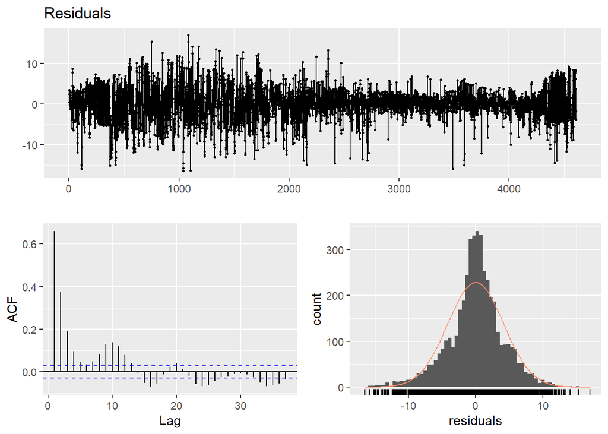

```
##
##  Breusch-Godfrey test for serial correlation of order up to 31
##
## data:  Residuals
## LM test = 2160.9, df = 31, p-value < 2.2e-16
```

Though the constant variance assumption is still violated, the variance within the residuals have decreased as there are no values left higher than 20 or lower than -20. A better and more suitable fit for normal distribution is attained by the model. It is obvious that the auto-correlations at certain lags increase as discussed before, however auto-correlation at lag 20 seem to be on the verge of significance. A last model, using the predictor variable via shifting the residuals by 20 units in time, which is two days in this case can be obtained,

```
##
## Call:
## lm(formula = Production ~ as.factor(Hour) + as.factor(month(Date)) +
##     mean_cl + mean_fl + avg_tmp + lag, data = out %>% filter(Date >
##     "2019-10-10" & Date < "2020-11-30"))
##
## Residuals:
##      Min       1Q   Median       3Q      Max
## -16.9918  -2.0122   0.1398   2.2697  16.6135
##
## Coefficients:
##                            Estimate Std. Error t value Pr(>|t|)
## (Intercept)              -3.984e+01  6.325e+00  -6.299 3.29e-10 ***
## as.factor(Hour)7          4.200e+00  8.678e-01   4.840 1.34e-06 ***
## as.factor(Hour)8          8.749e+00  8.236e-01  10.623  < 2e-16 ***
## as.factor(Hour)9          1.372e+01  8.218e-01  16.701  < 2e-16 ***
## as.factor(Hour)10         1.312e+01  8.541e-01  15.366  < 2e-16 ***
## as.factor(Hour)11         1.396e+01  8.633e-01  16.165  < 2e-16 ***
## as.factor(Hour)12         1.310e+01  8.710e-01  15.036  < 2e-16 ***
## as.factor(Hour)13         1.187e+01  8.765e-01  13.540  < 2e-16 ***
## as.factor(Hour)14         1.028e+01  8.771e-01  11.718  < 2e-16 ***
## as.factor(Hour)15         7.273e+00  8.767e-01   8.296  < 2e-16 ***
## as.factor(Hour)16         4.663e+00  8.532e-01   5.465 4.88e-08 ***
## as.factor(Hour)17         1.996e+00  8.312e-01   2.402 0.016367 *
## as.factor(Hour)18         6.481e-01  8.371e-01   0.774 0.438861
## as.factor(Hour)19        -1.007e+00  8.678e-01  -1.160 0.246185
## as.factor(month(Date))2   1.298e+00  3.556e-01   3.651 0.000265 ***
## as.factor(month(Date))3   7.667e-01  3.985e-01   1.924 0.054437 .
## as.factor(month(Date))4   2.945e+00  4.399e-01   6.694 2.43e-11 ***
## as.factor(month(Date))5   4.220e+01  6.265e+00   6.737 1.82e-11 ***
## as.factor(month(Date))6   4.172e+01  6.273e+00   6.651 3.26e-11 ***
## as.factor(month(Date))7   4.109e+01  6.277e+00   6.546 6.57e-11 ***
## as.factor(month(Date))8   4.177e+01  6.277e+00   6.654 3.18e-11 ***
## as.factor(month(Date))9   4.175e+01  6.280e+00   6.648 3.31e-11 ***
## as.factor(month(Date))10  1.675e+00  5.137e-01   3.260 0.001122 **
## as.factor(month(Date))11  6.602e-01  3.718e-01   1.776 0.075848 .
## as.factor(month(Date))12 -7.274e-01  3.676e-01  -1.979 0.047888 *
## mean_cl                  -6.604e-02  2.883e-03 -22.903  < 2e-16 ***
## mean_fl                   1.298e-02  4.154e-04  31.242  < 2e-16 ***
## avg_tmp                   1.383e-01  2.280e-02   6.067 1.41e-09 ***
## lag                       4.330e-02  1.507e-02   2.873 0.004090 **
## ---
## Signif. codes:  0 '***' 0.001 '**' 0.01 '*' 0.05 '.' 0.1 ' ' 1
##
## Residual standard error: 4.165 on 4559 degrees of freedom
## Multiple R-squared:  0.7843, Adjusted R-squared:  0.783
## F-statistic:   592 on 28 and 4559 DF,  p-value: < 2.2e-16
```

The regressor is shown to be statistically significant. Nevertheless, residual standard error have increased and R squared value have decreased a little. It can be stated that both models are valid. However, to keep the forecasting task easier and less complex, the first model without auto regressors is selected. If the forecasts of the test period are constructed in an iterative manner by updating the parameters of the model,

```
##           Date Hour Production      fit  residual
##  1: 2020-12-01    0       0.00 0.000000  0.000000
##  2: 2020-12-01    1       0.00 0.000000  0.000000
##  3: 2020-12-01    2       0.00 0.000000  0.000000
##  4: 2020-12-01    3       0.00 0.000000  0.000000
##  5: 2020-12-01    4       0.00 0.000000  0.000000
##  6: 2020-12-01    5       0.00 0.000000  0.000000
##  7: 2020-12-01    6       0.00 0.000000  0.000000
##  8: 2020-12-01    7       0.00 0.000000  0.000000
##  9: 2020-12-01    8       1.51 0.000000  1.510000
## 10: 2020-12-01    9       5.29 9.610367 -4.320367
```

## Model Testing and Brief Comments

By use of some statistics, some comments can be made about the obtained forecasts for the test period. For the linear regression model, some stats are,

```
##      n    mean       sd     FBias      MAD    WMAPE
## 1 1488 4.75705 8.160993 0.1352593 2.116811 0.444984
```

The WMAPE is much high and it can be concluded that the performance of the model is not much satisfactory. This actually is a surprising result as the model yielded a good enough performance on the train period. However, it should be noted that production of solar energy is rather random and since the produced values are small, a small residual might contribute as a high percentage to the WMAPE. If the performance of the ARIMA powered model on the test period is gathered,

```
##      n    mean       sd      FBias      MAD     WMAPE
## 1 1488 4.75705 8.160993 0.01130007 2.253883 0.4737985
```

## Conclusion

Predicting the hourly solar energy production series is a hard and rather tedious job. The series are not bound or regulated by any human intervention so most seasonality are only weak. Furthermore, there are several factors that are related to weather conditions. In a prediction setting, where predictions are made considering 36 hours ahead; trusting on the weather forecasts might already be misleading. Moreover, the extent of correlations change from season to season leading to future complications and adjustment.

Series being hourly is also another problem as in some hours there are small productions whereas in the same hours next or previous days there might be no production. It can be stated that from hourly series side, a model with significantly satisfactory training performance might face reduced performance in a test period. There are more advanced techniques to apply such as building models for each hour or using exponential smoothing. Nevertheless, it should be noted that the aim of this work is not to provide pure forecasts but to discuss series within the forecasting domain and state possible approaches, improvements or shortcomings.

In this study two different methods to predict hourly series are used. Keeping all the previous discussion in mind, selecting linear regression to predict hourly amount of solar plant production seems more reasonable for some reasons. First of all, the interest variable is correlated to some exogenous variables with changing extent thorough the year and more advanced use of these variables may lead to an improved performance. An addition to exogenous variables can be that if there occurs extreme situations with temperature or cloud layers in an unexpected period of the year, the effects are better and possibly faster brought to the predictions. Time series on the other hand may delay the effect of these unprecedented situations leading to distortion in both current and future values since these can be seen as errors to smoothed or lagged. Lastly, the seasonality used in the time series decomposition might be artificial and may not be existent in the future as there are no reasonable seasonality other than weakly annual one for the daily series.

Daily aggregated forecasts versus productions can be shown by,

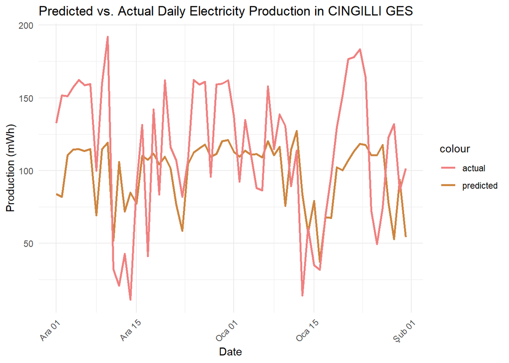

As can be seen, the model is short of grasping the random peaks in the production behavior. Hourly residuals can be shown by,

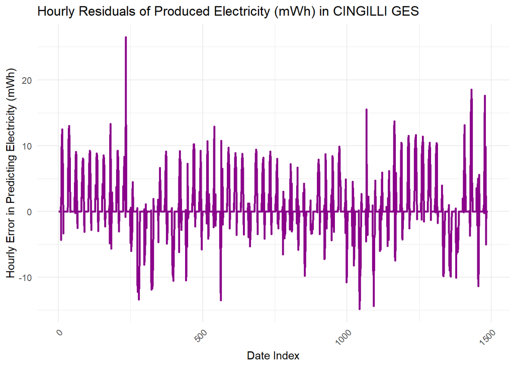

## References

[Solar Energy Factors](https://www.supercomputingchallenge.org/14-15/finalreports/88.pdf) • [R data.table Cheat Sheet](https://s3.amazonaws.com/assets.datacamp.com/blog_assets/datatable_Cheat_Sheet_R.pdf) • [Colors](http://sape.inf.usi.ch/quick-reference/ggplot2/colour) • [Advanced Solar Energy Production](https://www.researchgate.net/publication/284206500_Impact_of_Trend_and_Seasonality_in_Forecasting_of_5_MW_PV_Plant_Generation_using_Single_Exponential_Smoothing_Method)

## Appendices

RMD file is sent via e-mail.